# Regressions, PCA, Clustering

#### 1. f) Try improve Linear Model w PCA 4 Dim Reduction.

Next up, is trying to improve the Linear Model by first performing principal component analysis. To do so however, I first need to convert my factor variables to series of dummies, from which distances can be calculated. I use dummyVars() from caret to define these dummies, & re-create my original dataframe called tdf. Then I re-create the training & holdout sets, and use prcomp() to evaluate principal components. I found the first 35 PCs to explain 99.9% of total variance, & 60 PCs to explain 99.99% of variance. The number of principal components used to arrive at the best OLS model was 117, so this was the number of PCs I used to re-estimate all penalized models as well. To see a comparison of all PCA-based models vs their original “best” counterparts, please visit the table under 1.h). For the OLS model, the decline performance is substantial: over 13% decline in MAE, over 14% decline in RMSE, & 6.8% decline in R-squared.

```r
    #   Center & Scale variables -> use pcr 2 find optimal number of PCs
    #   Does PCA Improve fit over simple linear models
    #     # Many factor variables -> Include 60-90 PCs in search as well

#    preProcess = c("center", "scale", "pca"),

#   1) Pre-Processing -> removing factors
      # Other factors -> dummy variable table -> dummyVars
        #   -> will probably result in smaller variances -> hence 60 - 90 PCs

# Using dummyVars to make factor variables -> make new dataframe basically
dummies <- dummyVars(Formula, data = df)
tdf <- cbind("logTotalValue" = df$logTotalValue,predict(dummies,newdata = df) %>% as.data.frame())

#### Sample vs Holdout sets
set.seed(1234)
train_indices <- as.integer(createDataPartition(tdf$logTotalValue, p = 0.3, list = FALSE))
data_train <- tdf[train_indices, ]
data_holdout2 <- tdf[-train_indices, ]

#### OLS w PCA ####
PCA_tdf <- prcomp(tdf)
Summary <- PCA_tdf %>% summary()
PCA_Summ_df <- Summary$importance %>% rbind() %>% as.data.frame() %>% transpose() %>% cbind(index = 1:300)
colnames(PCA_Summ_df) <- c("StDev","Prop%_Variance","CumSum_Prop%_Variance","index")
# PC35 -> 99.9% of total variance -> PC60 = 99.99%

trctrlWithPCA <- trainControl(method = "cv", number = 10, verboseIter = FALSE)
tune_grid <- data.frame(ncomp = 35:120)

set.seed(1234)
  ols_model_pca <- train(
    logTotalValue ~ .,
    data = data_train,
    method = "pcr",
    preProcess = c("center", "scale"),
    tuneGrid = tune_grid,
    trControl = trctrlWithPCA)

#     ncomp = 117 is optimal
```

#### 1.g) Applying PCA to penalized models via perProcess -> achieves better fit?

After estimating the optimal number of PCs on the OLS model, this number was used on penalized models, by adding preProcOptions to train_control. Also once removing near-zero variances, 121 Principal Components remained. Overall, penalized models also declined in performance vs their best-fit formulations, though less starkly vs the OLS models. The RIDGE pca model also performed very similarly to the LASSO, while in their original formulations the Ridge model was over 2% worse in MAE & RMSE, and 1% lower in R-squared. Also, the Elastic Net using PCA return an optimal alpha parameter of 1, i.e. it reduced to a LASSO model, returning identical performance metrics as the LASSO pca. As such, the LASSO pca is the best model using Principal Component Analysis.

```r
    #   Include "nzv" to preProcess also -> Drops zero variance features
      # What's your intuition, why is this happening ?

### LASSO PCA ----

lasso_tune_grid <- expand.grid(
  "alpha" = c(1),
  "lambda" = 10^seq(0,-5.5,length=100))

set.seed(1234)
  lasso_fit_pca <- train(
    logTotalValue ~ .,
    data = data_train,
    method = "glmnet",
    preProcess = c("center", "scale","nzv","pca"),
    tuneGrid = lasso_tune_grid,
    trControl = trainControl(method = "cv",number = 10,preProcOptions = list(pcaComp = 117))
  )

### RIDGE PCA ----
ridge_tune_grid <- expand.grid(
  "alpha" = c(0),
  "lambda" = 10^seq(4,-5.5,length=200)
)

set.seed(1234)
  ridge_fit_pca <- train(
    logTotalValue ~ .,
    data = data_train,
    method = "glmnet",
    preProcess = c("center", "scale","nzv","pca"),
    tuneGrid = ridge_tune_grid,
    trControl = trainControl(method = "cv",number = 10,preProcOptions = list(pcaComp = 117))
  )

### Elastic Net PCA ----
enet_tune_grid <- expand.grid(
  "alpha" = seq(0.7, 1, by = 0.03),
  "lambda" = union(lasso_tune_grid[["lambda"]], ridge_tune_grid[["lambda"]]))

set.seed(1234)
  enet_fit_pca <- train(
    logTotalValue ~ .,
    data = data_train,
    method = "glmnet",
    preProcess = c("center", "scale","nzv","pca"),
    tuneGrid = enet_tune_grid,
    trControl = trainControl(method = "cv",number = 10,preProcOptions = list(pcaComp = 117))
  )
```

# h) Select best model trained -> Evaluate your preferred model on test set

```r
#### Summary ----

Resamples_w_pca <- resamples(
  list("OLS" = ols_model,
       "OLS_PCA" = ols_model_pca,
       "RIDGE" = ridge_fit,
       "RIDGE_PCA" = ridge_fit_pca,
       "LASSO" = lasso_fit,
       "LASSO_PCA" = lasso_fit_pca,
       "Elastic Net" = enet_fit,
       "Elastic_Net_PCA" = enet_fit_pca
       ))

Models <- list("OLS" = ols_model       ,"OLS_PCA" = ols_model_pca,
               "RIDGE" = ridge_fit     ,"RIDGE_PCA" = ridge_fit_pca,
               "LASSO" = lasso_fit     ,"LASSO_PCA" = lasso_fit_pca,
               "Elastic Net" = enet_fit,"Elastic_Net_PCA" = enet_fit_pca)


PCA_SummTable <- lapply(names(Models), function(x) {
  tdf <-  Resamples_w_pca$values %>% dplyr::select(matches(x))
  tl <- list()

  tl[['Regr.Model']] <- x
  tl[['CV_MAE']] <- (tdf %>% dplyr::select(matches("MAE")))[[1]] %>% mean() %>% round(4)
  tl[['CV_RMSE']] <- (tdf %>% dplyr::select(matches("RMSE")))[[1]] %>% mean() %>% round(4)
  tl[['CV_R^2']] <- (tdf %>% dplyr::select(matches("Rsquared")))[[1]] %>% mean() %>% round(4)

  return(tl)
}) %>% rbindlist()


PCA_SummTable %>% kable()
```

| Regr.Model | CV_MAE | CV_RMSE | CV_R^2 |
| --- | --- | --- | --- |
| OLS | 0.3773 | 0.5218 | 0.8881 |
| OLS_PCA | 0.5106 | 0.6625 | 0.8203 |
| RIDGE | 0.3988 | 0.5275 | 0.8866 |
| RIDGE_PCA | 0.3993 | 0.5498 | 0.8772 |
| LASSO | 0.3771 | 0.5025 | 0.8967 |
| LASSO_PCA | 0.3994 | 0.5447 | 0.8785 |
| Elastic Net | 0.3768 | 0.5025 | 0.8968 |
| Elastic_Net_PCA | 0.3994 | 0.5447 | 0.8785 |

```r
data_holdout$pred_E.Net <- predict(enet_fit,newdata = data_holdout)
Hd_RMSE <- RMSE(data_holdout$pred_E.Net,data_holdout$logTotalValue) %>% round(4)
Hd_MAE <-  MAE(data_holdout$pred_E.Net,data_holdout$logTotalValue) %>% round(4)

data_holdout2$pred_E.NetPca <- predict(enet_fit_pca,newdata = data_holdout2)
Hd_RMSE_Pc <- RMSE(data_holdout2$pred_E.NetPca,data_holdout2$logTotalValue) %>% round(4)
Hd_MAE_Pc <-  MAE(data_holdout2$pred_E.NetPca,data_holdout2$logTotalValue) %>% round(4)

HoldoutSumms <- rbind(cbind(Hd_RMSE,Hd_MAE),cbind(Hd_RMSE_Pc,Hd_MAE_Pc)) %>% as.data.frame()

rownames(HoldoutSumms) <- c("Best_Elastic_Net","Elastic_Net_PCA")
HoldoutSumms %>% kable()
```

|  | Hd_RMSE | Hd_MAE |
| --- | --- | --- |
| Best_Elastic_Net | 0.5031 | 0.3774 |
| Elastic_Net_PCA | 0.5386 | 0.3990 |

#### 2) Clustering on the USArrests dataset

The 2nd chapter of this exercise uses the USArrests dataset, to cluster US states. As part of understanding the data, I use the GGally librarys’ ggpairs function to get scatter plot, variable density-plots & correlations simultaneously. The plots below 1st weakly skewed variables except for Urban Population, & moderate to strong correlations among Murders & Assault, Murders & Rape, and Assault & Rape. 1 could argue the reason for this is some assaults escalating to rapes to occur, & some rapes to also result in murders.

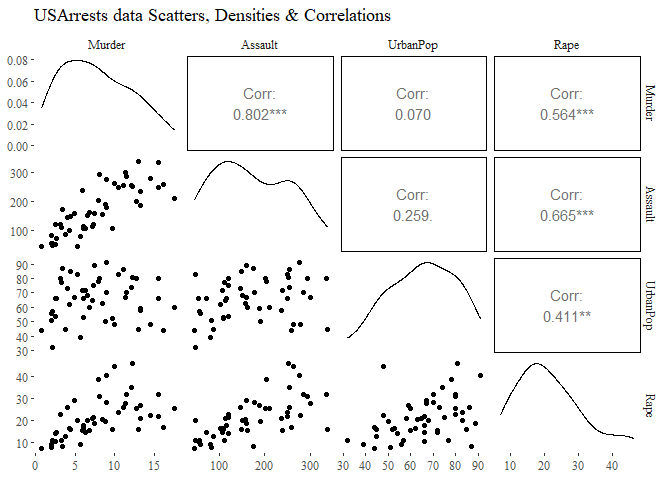

```r
  #   Task: Apply Clustering -> make sense of clusters with PCA
  #   Data used in Class

library(tidyverse)
library(caret)
library(skimr)
library(janitor)
library(factoextra) # provides nice functions for visualizing the output of PCA
library(NbClust) # for choosing the optimal number of clusters
library(knitr)
library(kableExtra)

theme_set(theme_tufte())

data <- USArrests
ggally <- GGally::ggpairs(data, title = "USArrests data Scatters, Densities & Correlations")

ggally
```

#### 2. a) Any data pre-processing you may / should / could / would do ?

To be able to calculate Principal Components, or perform K-means clustering, I scale the data with the stats librarys’ scale() function.

```r
      #   Scale variables
data_scaled <- scale(data) %>% as.data.frame()
```

#### 2. b) Determine optimal number of clusters as indicated by NbClust heuristics

To determine optimal number of clusters for K-means clustering, I use the NbClust() function, trying any number of clusters from 2 to 10.

```r
nb <- NbClust(data_scaled, method = "kmeans", min.nc = 2, max.nc = 10, index = "all")
```

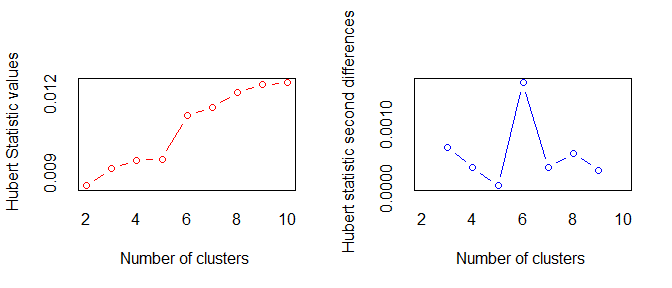

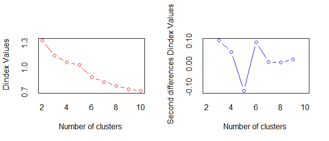

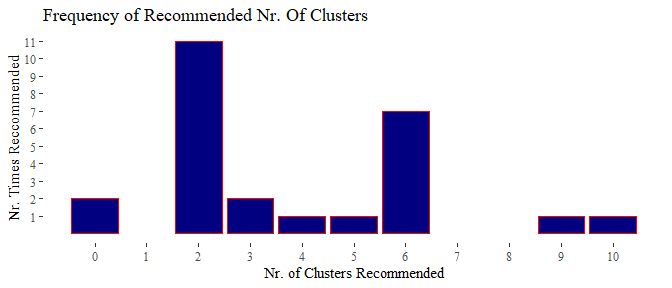

```r
Cluster <- nb$Best.nc["Number_clusters",] %>% cbind() %>% as.data.frame()
colnames(Cluster) <- "Optimal_Cluster_Nr"

NrClustsRec <- Cluster %>%
    ggplot(aes(x = Optimal_Cluster_Nr)) +
    geom_bar(color = "red", fill = "navy") +
    scale_x_continuous(labels = c(0:10), breaks = c(0:10)) +
    scale_y_continuous(labels = c(1:11), breaks = c(1:11)) +
    labs(title = "Frequency of Recommended Nr. Of Clusters",
         y = "Nr. Times Reccommended",
         x = "Nr. of Clusters Recommended")

NrClustsRec
```

#### 2 c) Use K-means to Cluster states using Nr. Clusters found in b)

Below I use the most voted number of clusters (obtained fomr above) to cluster observations, with 30 starting points. I add the resulting cluster designations to my original data frame, & color the clusters while depicting Urban Population vs Murder, Assault & Rape. The plots below show that largely, K-means seems to assign clusters based on these 3 variables.

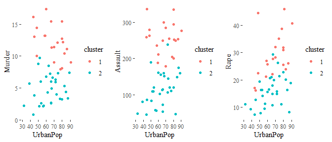

```r
km <- kmeans(data_scaled, centers = nb$Best.partition %>% unique() %>% length(),
             nstart = 30)

data_w_clusters <- mutate(data, cluster = factor(km$cluster))

# Murder
Murder <- data_w_clusters %>%
  ggplot(aes(x = UrbanPop, y = Murder,  color = cluster)) +
  geom_point( )

# Assault
Assault <- ggplot(data_w_clusters, aes(x = UrbanPop, y = Assault, color = cluster)) +geom_point()

# Rape
Rape <- ggplot(data_w_clusters, aes(x = UrbanPop, y = Rape, color = cluster)) +  geom_point()

grid.arrange(Murder, Assault, Rape, ncol = 3)
```

#### 2 d) Do PCA & Get 1st 2 PC coordinates 4 all observations:

In this final section, the 1st 2 Principal Components are obtain from the raw data, & data points are visualized from perspective of the 2 principal components, after assigned clusters are added to the dataframe. The plot below shows a clear line of de-markation at ca. PC1 = -0.1. The question remaining is what these principal components do most significantly take into account, as well as what seperates these identified clusters.

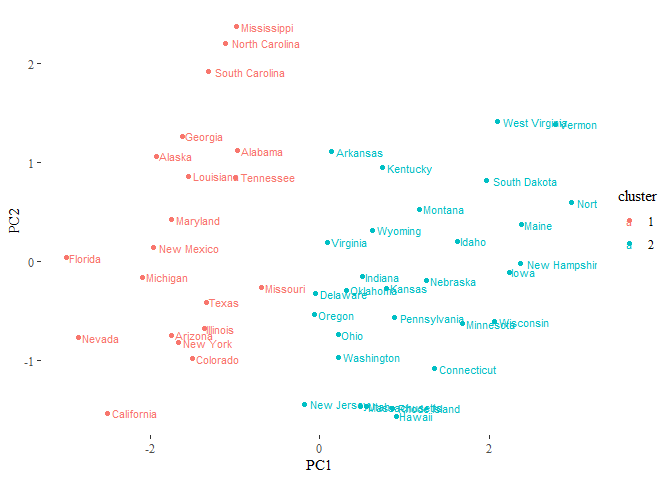

```r
pca_result <- prcomp(data,scale = T)

Cities <- rownames(pca_result$x)

first_two_pc <- pca_result$x[,1:2] %>% as.data.frame()
first_two_pc <- first_two_pc %>%
  mutate(cluster = factor(km$cluster),City = Cities)
rownames(first_two_pc) <- Cities

    #   Plot clusters of choice along co-ordinate system of 1st 2 PCs

PC12Plot <- first_two_pc %>% ggplot(aes(x = PC1,y = PC2, color = cluster)) +
  geom_point() +geom_text(label = Cities, size = 3, hjust = -0.1)

  # Very clear Seperation along PC1

#   How do clusters relate to these?
ClusterTable <- data_w_clusters %>% group_by(cluster) %>%
  summarize(StateCount = n(),
            AvgMurder = mean(Murder)     ,AvgAssault = mean(Assault),
            AvgUrbanPop = mean(UrbanPop) ,AvgRape = mean(Rape))
  # Cluster 2 ca. 3x Murder / 2x Assault / 2x Rape
    # Safe vs Unsafe seems an intuitive cluster title
      # Weights used to project observations along PCs helps this further:

PC12_Weights <- pca_result$rotation[,1:2] %>% round(4)

PC1_Cont <- fviz_contrib(pca_result, "var", axes = 1) # Crime-related
PC2_Cont <- fviz_contrib(pca_result, "var", axes = 2) # Population-related

PC12Plot
```

```r
ClusterTable %>% kable()
```

| cluster | StateCount | AvgMurder | AvgAssault | AvgUrbanPop | AvgRape |
| --- | --- | --- | --- | --- | --- |
| 1 | 20 | 12.165 | 255.2500 | 68.40000 | 29.16500 |
| 2 | 30 | 4.870 | 114.4333 | 63.63333 | 15.94333 |

```r
PC12_Weights %>% kable()
```

|  | PC1 | PC2 |
| --- | --- | --- |
| Murder | -0.5359 | 0.4182 |
| Assault | -0.5832 | 0.1880 |
| UrbanPop | -0.2782 | -0.8728 |
| Rape | -0.5434 | -0.1673 |

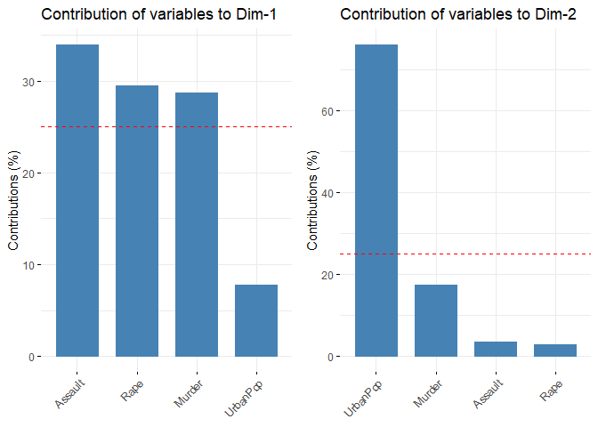

```r
grid.arrange(PC1_Cont,PC2_Cont, ncol = 2)
```

A 1st table above calculates variable mean by cluster. 1 can see that cluster 1 vs cluster 2, the average number of murders is 2.5x, average number of assaults & rapes are 2x. Thus, 1 way to interpret the clusters may be Safe vs Unsafe. The 2nd table shows the explicit weights used per variable to derive observation coordinates from perspective of the first 2 Principal Components, while the bar charts that follow depict variable significance/contribution for a PC. Indeed, 1 can see that the 1st Principal Component primarily takes into account crime-related variables, while the 2nd PC overwhelmingly focuses on Urban Population.

# Appendices

### Raw Histograms, Box- & Scatterplots

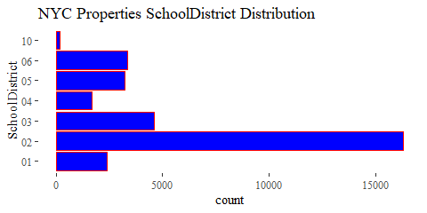

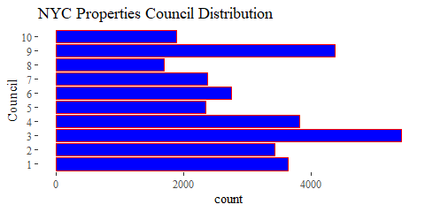

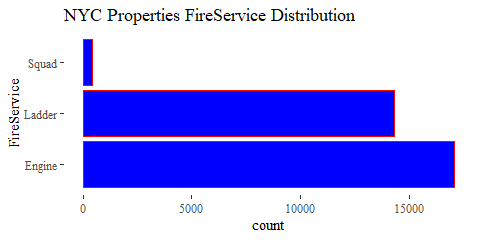

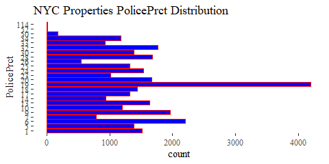

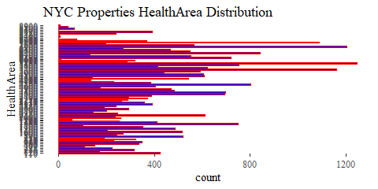

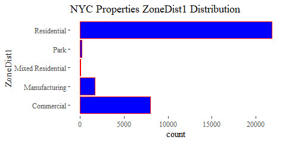

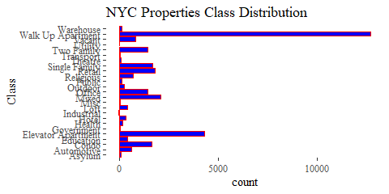

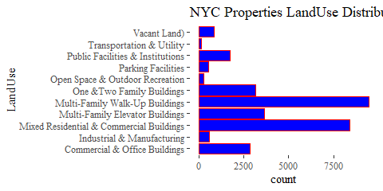

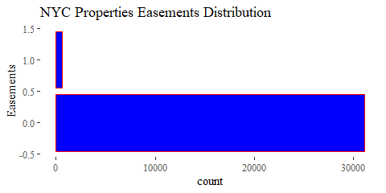

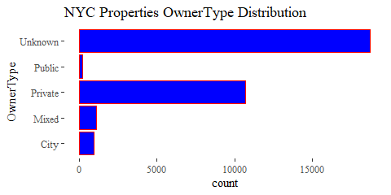

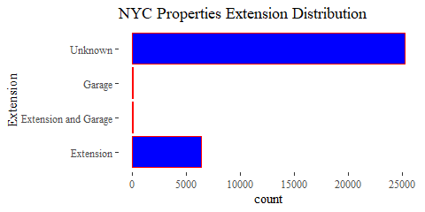

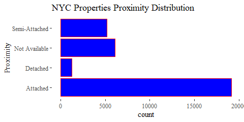

[108 more figures not shown]

```r
Hists()
```

### Transformed Box- & Scatterplots

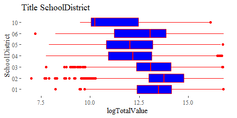

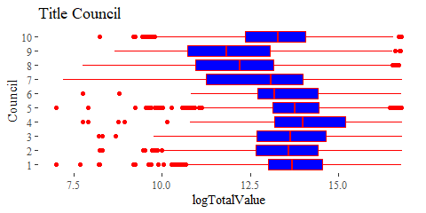

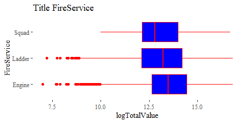

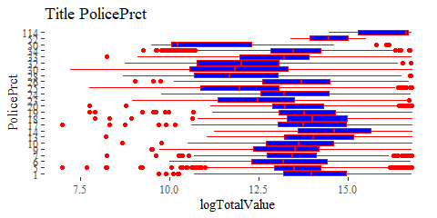

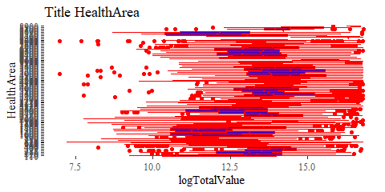

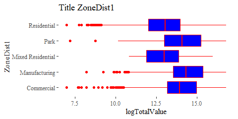

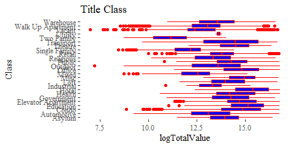

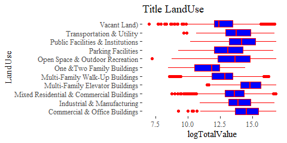

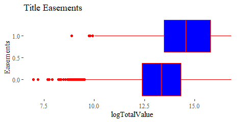

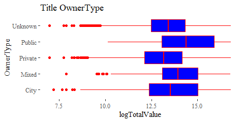

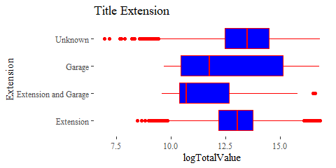

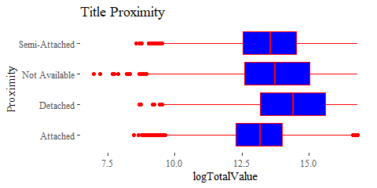

[71 more figures not shown]

```r
Boxes_n_Scatters()
```